# Internet Users and GDP Relations in ASEAN Countries

```python
import pandas as pd
import cufflinks as cf
import seaborn as sn
from IPython.display import display, HTML

cf.set_config_file(sharing="public", theme="space", offline=True)
```

```python
# Importing dataframes
df_internet = pd.read_csv("final.csv")
df_gdp = pd.read_csv("world_gdp.csv")
```

The data above were retrieved from kaggle:

- df_internet = https://www.kaggle.com/datasets/ashishraut64/internet-users
- df_gdp = https://www.kaggle.com/datasets/tmishinev/world-country-gdp-19602021

```python
df_internet.sample(5)
```

|  | Unnamed: 0 | Entity | Code | Year | Cellular Subscription | Internet Users(%) | No. of Internet Users | Broadband Subscription |
| --- | --- | --- | --- | --- | --- | --- | --- | --- |
| 7624 | 7624 | Sudan | SDN | 2020 | 80.264084 | 28.400000 | 12621097 | 0.065639 |
| 6388 | 6388 | Peru | PER | 1989 | 0.000000 | 0.000000 | 0 | 0.000000 |
| 3684 | 3684 | India | IND | 2013 | 69.196991 | 12.300000 | 158809242 | 1.165457 |
| 5490 | 5490 | Morocco | MAR | 1993 | 0.025712 | 0.000000 | 0 | 0.000000 |
| 2909 | 2909 | Gambia | GMB | 1997 | 0.394327 | 0.051311 | 676 | 0.000000 |

```python
df_gdp.sample(5)
```

|  | Country Name | Country Code | year | GDP_USD | GDP_per_capita_USD |
| --- | --- | --- | --- | --- | --- |
| 1739 | Lithuania | LTU | 1966 | NaN | NaN |
| 10927 | Bulgaria | BGR | 2001 | 1.418350e+10 | 1770.913534 |
| 6543 | Malta | MLT | 1984 | 1.101829e+09 | 3332.885357 |
| 11941 | Timor-Leste | TLS | 2004 | 4.407646e+08 | 453.513313 |
| 11075 | Malaysia | MYS | 2001 | 9.278395e+10 | 3913.429386 |

```python
# Renaming column for merging dataframes and reference
df_gdp.rename(columns={"year":"Year",
                "Country Code":"Country_Code"}, inplace=True)

df_internet.rename(columns={"Code":"Country_Code"}, inplace=True)

# Merge dataframes
df_main = df_internet.merge(df_gdp[["Year", "Country_Code", "GDP_USD", "GDP_per_capita_USD"]], on=["Year", "Country_Code"], how="left")
df_main.sample(5)
```

|  | Unnamed: 0 | Entity | Country_Code | Year | Cellular Subscription | Internet Users(%) | No. of Internet Users | Broadband Subscription | GDP_USD | GDP_per_capita_USD |
| --- | --- | --- | --- | --- | --- | --- | --- | --- | --- | --- |
| 3329 | 3329 | Guinea-Bissau | GNB | 1985 | 0.000000 | 0.000000 | 0 | 0.000000 | 1.438563e+08 | 164.941935 |
| 3551 | 3551 | Hong Kong | HKG | 2003 | 109.287064 | 52.200043 | 3594737 | 18.855419 | 1.613850e+11 | 23977.019450 |
| 830 | 830 | Bermuda | BMU | 1982 | 0.000000 | 0.000000 | 0 | 0.000000 | 7.855000e+08 | 14166.171290 |
| 3263 | 3263 | Guatemala | GTM | 2000 | 7.354303 | 0.712333 | 83599 | 0.000000 | 1.928883e+10 | 1664.298958 |
| 6053 | 6053 | North Macedonia | MKD | 2002 | 17.831081 | 17.330000 | 357819 | 0.000000 | 4.018365e+09 | 1989.135125 |

```python
# Filter ASEAN Countries
asean_list = ["IDN", "KHM", "SGP", "VNM", "MMR", "THA", "BRN", "LAO", "MYS", "PHL"]
df_asean = df_main[df_main["Country_Code"].isin(asean_list)]
df_asean
df_asean.sample(5)
```

|  | Unnamed: 0 | Entity | Country_Code | Year | Cellular Subscription | Internet Users(%) | No. of Internet Users | Broadband Subscription | GDP_USD | GDP_per_capita_USD |
| --- | --- | --- | --- | --- | --- | --- | --- | --- | --- | --- |
| 6420 | 6420 | Philippines | PHL | 1980 | 0.000000 | 0.000000 | 0 | 0.000000 | 3.684824e+10 | 778.082780 |
| 5570 | 5570 | Myanmar | MMR | 1991 | 0.000000 | 0.000000 | 0 | 0.000000 | 2.137185e+09 | 51.018741 |
| 7906 | 7906 | Thailand | THA | 2015 | 149.811157 | 39.316128 | 27637039 | 9.065043 | 4.012960e+11 | 5840.053067 |
| 3731 | 3731 | Indonesia | IDN | 2019 | 126.106911 | 47.690647 | 128565820 | 3.800219 | 1.119100e+12 | 4135.233344 |
| 1100 | 1100 | Brunei | BRN | 1987 | 0.000000 | 0.000000 | 0 | 0.000000 | 2.754463e+09 | 11594.567540 |

```python
# checking for null values
df_asean.isnull().sum()
```

```
Unnamed: 0                 0
Entity                     0
Country_Code               0
Year                       0
Cellular Subscription      0
Internet Users(%)          0
No. of Internet Users      0
Broadband Subscription     0
GDP_USD                   22
GDP_per_capita_USD        22
dtype: int64
```

```python
# finding null locations
temp = df_asean.isnull().any(axis=1)
temp[temp].index
```

```
Index([1256, 1257, 1258, 1259, 1260, 1261, 1262, 1263, 1264, 1265, 1266, 1267,
       1268, 4262, 4263, 4264, 4265, 8662, 8663, 8664, 8665, 8666],
      dtype='int64')
```

```python
# reviewing null values
df_asean.loc[[1256, 1257, 1258, 1259, 1260, 1261, 1262, 1263, 1264, 1265, 1266, 1267,
       1268, 4262, 4263, 4264, 4265, 8662, 8663, 8664, 8665, 8666], :]
```

|  | Unnamed: 0 | Entity | Country_Code | Year | Cellular Subscription | Internet Users(%) | No. of Internet Users | Broadband Subscription | GDP_USD | GDP_per_capita_USD |
| --- | --- | --- | --- | --- | --- | --- | --- | --- | --- | --- |
| 1256 | 1256 | Cambodia | KHM | 1980 | 0.0 | 0.0 | 0 | 0.0 | NaN | NaN |
| 1257 | 1257 | Cambodia | KHM | 1981 | 0.0 | 0.0 | 0 | 0.0 | NaN | NaN |
| 1258 | 1258 | Cambodia | KHM | 1982 | 0.0 | 0.0 | 0 | 0.0 | NaN | NaN |
| 1259 | 1259 | Cambodia | KHM | 1983 | 0.0 | 0.0 | 0 | 0.0 | NaN | NaN |
| 1260 | 1260 | Cambodia | KHM | 1984 | 0.0 | 0.0 | 0 | 0.0 | NaN | NaN |
| 1261 | 1261 | Cambodia | KHM | 1985 | 0.0 | 0.0 | 0 | 0.0 | NaN | NaN |
| 1262 | 1262 | Cambodia | KHM | 1986 | 0.0 | 0.0 | 0 | 0.0 | NaN | NaN |
| 1263 | 1263 | Cambodia | KHM | 1987 | 0.0 | 0.0 | 0 | 0.0 | NaN | NaN |
| 1264 | 1264 | Cambodia | KHM | 1988 | 0.0 | 0.0 | 0 | 0.0 | NaN | NaN |
| 1265 | 1265 | Cambodia | KHM | 1989 | 0.0 | 0.0 | 0 | 0.0 | NaN | NaN |
| 1266 | 1266 | Cambodia | KHM | 1990 | 0.0 | 0.0 | 0 | 0.0 | NaN | NaN |
| 1267 | 1267 | Cambodia | KHM | 1991 | 0.0 | 0.0 | 0 | 0.0 | NaN | NaN |
| 1268 | 1268 | Cambodia | KHM | 1992 | 0.0 | 0.0 | 0 | 0.0 | NaN | NaN |
| 4262 | 4262 | Laos | LAO | 1980 | 0.0 | 0.0 | 0 | 0.0 | NaN | NaN |
| 4263 | 4263 | Laos | LAO | 1981 | 0.0 | 0.0 | 0 | 0.0 | NaN | NaN |
| 4264 | 4264 | Laos | LAO | 1982 | 0.0 | 0.0 | 0 | 0.0 | NaN | NaN |
| 4265 | 4265 | Laos | LAO | 1983 | 0.0 | 0.0 | 0 | 0.0 | NaN | NaN |
| 8662 | 8662 | Vietnam | VNM | 1980 | 0.0 | 0.0 | 0 | 0.0 | NaN | NaN |
| 8663 | 8663 | Vietnam | VNM | 1981 | 0.0 | 0.0 | 0 | 0.0 | NaN | NaN |
| 8664 | 8664 | Vietnam | VNM | 1982 | 0.0 | 0.0 | 0 | 0.0 | NaN | NaN |
| 8665 | 8665 | Vietnam | VNM | 1983 | 0.0 | 0.0 | 0 | 0.0 | NaN | NaN |
| 8666 | 8666 | Vietnam | VNM | 1984 | 0.0 | 0.0 | 0 | 0.0 | NaN | NaN |

```python
df_asean.dropna(inplace=True)
```

```python
# filter year
df_asean = df_asean[df_asean["Year"] > 1989]
```

### Southeast Asia Internet User Growth

```python
# pivot table
a = df_asean.pivot(index="Year", columns="Entity", values="Internet Users(%)")

# fill 0 values
a.loc[2018, "Cambodia"] = a.loc[2018, :].median()
a.loc[2019, "Cambodia"] = a.loc[2019, :].median()
a.loc[2020, "Cambodia"] = a.loc[2020, :].median()

a.iplot(kind="line",  xTitle="Year", yTitle="Users(%)")
```

[interactive chart not shown]

Countries that were early adopters of the internet, such as Brunei, Singapore, and Malaysia, generally have a higher percentage of internet users than others. Additionally, in 2015, there was a significant increase in user percentages in each country. There is a possibility that this sharp increase was caused by several factors, such as increased smartphone adoption, the rise of social media, and e-commerce growth.

### Internet User Percentage Rank in Southeast Asia (2020)

```python
a[a.index.isin([2020])].sort_values(2020, axis=1).iplot(kind="bar", xTitle="Year", yTitle="Users(%)")
```

[interactive chart not shown]

Despite Indonesia contributing 40.8% to the total population of the ASEAN region, it ranks among the countries with the lowest internet usage percentage with numbers barely reach 50%

### GDP Growth in Southeast Asia

```python
b = df_asean.pivot(index="Year", columns="Entity", values="GDP_USD")

b.iplot(kind="line", yTitle="GDP in USD", xTitle="Year")
```

[interactive chart not shown]

Although Indonesia has the highest GDP, only 53.73% of the population in Indonesia uses the internet. This data may indicate that there is a significant economic disparity in Indonesia or a low level of digital literacy.

### GDP per Capita In Southeast Asia

```python
c = df_asean.pivot(index="Year", columns="Entity", values="GDP_per_capita_USD")

c[c.index.isin([2020])].sort_values(2020, axis=1).iplot(kind="bar", yTitle="GDP/Capita", xTitle="Year")
```

[interactive chart not shown]

By examining the GDP per Capita and internet User Percentage (2020) barchart, we can conclude that countries with a high GDP per capita tend to have higher internet user percentage. Also, the chart above confirms the hypothesis about the economic disparity that is happening in Indonesia is true

### Linear Regression Model

```python
# removing outliers
max_limit = df_asean["Internet Users(%)"].mean() + 3 * df_asean["Internet Users(%)"].std()
min_limit = df_asean["Internet Users(%)"].mean() - 3 * df_asean["Internet Users(%)"].std()

df_asean2 = df_asean[(df_asean["Internet Users(%)"] < max_limit) & (df_asean["Internet Users(%)"] > min_limit)]
```

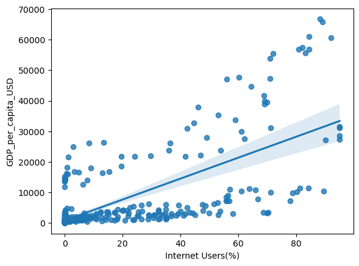

```python
sn.regplot(data=df_asean2, x="Internet Users(%)", y="GDP_per_capita_USD")
```